# Tubes 2 Pengenalan Komputasi (Data Analisis dan Visualisasi)

### Kelompok 4

| Nama | NIM |
| --- | --- |
| Frederic Ronaldi | 16519422 |
| Gavriel Benny | 16519032 |
| Aulia Adila | 16519152 |
| Abu Hanif Muhammad Syarubany | 16519282 |

## Tema: Penjualan Video Games Beserta Ratingnya

### Dataset yang digunakan:

1. Penjualan Video Games[(sumber)](https://www.kaggle.com/ashaheedq/video-games-sales-2019/data#vgsales-12-4-2019.csv)

   > Format: CSV

   > Ukuran file: 4.8MB

   > Dimensi: 55792 baris x 14 kolom
2. Penilaian Video Games dari Metacritic dan Pemain (format: csv)[(sumber)](https://www.kaggle.com/destring/metacritic-reviewed-games-since-2000)

   > Format: CSV

   > Ukuran file: 744KB

   > Dimensi: 15647 baris x 5 kolom

### Data yang akan dianalisis dan divisualisasi:

1. Game-game dengan penjualan terbanyak
2. Platform (seperti PS4, Wii, Nintendo DS, dsb.) dengan produksi game terbanyak
3. Perkembangan produksi game pada masing-masing platform sejalan dengan waktu
4. Publisher dengan game terbanyak
5. Developer dengan game terbanyak
6. Perkembangan penjualan game setiap tahun
7. Genre dengan produksi game terbanyak
8. Genre yang paling disuka dalam masing-masing tahun produksi
9. Banyaknya game sesuai kategori umur (ESRB Rating)
10. Relasi antara penjualan video games dengan penilaian video games dari pemain dan Metacritic
11. Relasi antara penilaian dari pemain dan Metacritic.

# Pendahuluan

### Import dan membaca data:

```python
import pandas as pd
import matplotlib.pyplot as plt
data1 = pd.read_csv("data1.csv")
data2 = pd.read_csv("data2.csv")
```

### Mencari dimensi dataset:

```python
print("Dimensi dataset 1: " + str(len(data1)) + " baris x " + str(len(data1.columns)) + " kolom")
print("Dimensi dataset 2: " + str(len(data2)) + " baris x " + str(len(data2.columns)) + " kolom")
```

```
Dimensi dataset 1: 55792 baris x 14 kolom
Dimensi dataset 2: 15647 baris x 5 kolom
```

### Kolom yang ada dalam dataset serta jenisnya:

```python
print("Nama-nama kolom pada dataset 1: ")
kolom1 = list(data1.columns)
kolom2 = list(data2.columns)
for index in range(len(kolom1)):
    print(str(index+1) + ". " + str(kolom1[index]) + " (" + str(data1.dtypes[str(kolom1[index])]) + ")")
print()
print("Nama-nama kolom pada dataset 2: ")
for index in range(len(kolom2)):
    print(str(index+1) + ". " + str(kolom2[index]) + " (" + str(data2.dtypes[str(kolom2[index])]) + ")")
```

```
Nama-nama kolom pada dataset 1:
1. Rank (int64)
2. Name (object)
3. Genre (object)
4. ESRB_Rating (object)
5. Platform (object)
6. Publisher (object)
7. Developer (object)
8. Total_Shipped (float64)
9. Global_Sales (float64)
10. NA_Sales (float64)
11. PAL_Sales (float64)
12. JP_Sales (float64)
13. Other_Sales (float64)
14. Year (float64)

Nama-nama kolom pada dataset 2:
1. metascore (int64)
2. name (object)
3. console (object)
4. userscore (object)
5. date (object)
```

**Kesimpulan** : *Terlihat bahwa jenis int64 adalah jenis integer, object dapat berupa string atau tipe kategorical, dan float adalah angka tidak bulat.*

### Karakteristik data untuk tiap kolom:

**Dataset 1:**

```python
data1null = data1.isnull().sum()
print("1. Rank (Ranking penjualan game terbanyak)")
print("Range: " + str(data1["Rank"].min()) + " - " + str(data1["Rank"].max()))
print("Jumlah data kosong: " + str(data1null["Rank"]))
print()
print("2. Name (Nama game tersebut)")
print("Nama game adalah unik untuk masing-masing game")
print("Jumlah data kosong: " + str(data1null["Name"]))
print()
print("3. Genre (Genre game tersebut)")
print("Genre adalah tipe kategorikal dengan kategori sebagai berikut: " + str(list(data1["Genre"].unique())))
print("Jumlah data kosong: " + str(data1null["Genre"]))
print()
print("4. ESRB Rating (ESRB Rating game tersebut)")
print("ESRB Rating adalah rating yang diberikan pada sesuatu karya untuk menandakan target usia yang terbilang normal untuk menikmati karya tersebut")
print("ESRB Rating adalah tipe kategorikal dengan kategori sebagai berikut: " + str(list(data1["ESRB_Rating"].unique())))
print("Jumlah data kosong: " + str(data1null["ESRB_Rating"]))
print()
print("5. Platform (Alat untuk memainkan game tersebut)")
print("Jumlah platform: " + str(len(data1["Platform"].unique())))
print("Jumlah data kosong: " + str(data1null["Platform"]))
print()
print("6. Publisher (Publisher game tersebut)")
print("Jumlah publisher: " + str(len(data1["Publisher"].unique())))
print("Jumlah data kosong: " + str(data1null["Publisher"]))
print()
print("7. Developer (Developer game tersebut)")
print("Jumlah developer: " + str(len(data1["Developer"].unique())))
print("Jumlah data kosong: " + str(data1null["Developer"]))
print()
print("8. Total Shipped (Total pengiriman game secara offline di seluruh dunia dalam juta dollars)")
print("Range: " + str(data1["Total_Shipped"].min()) + " - " + str(data1["Total_Shipped"].max()))
print("Jumlah data kosong: " + str(data1null["Total_Shipped"]))
print()
print("9. Global Sales (Total penjualan game secara online di seluruh dunia dalam juta dollars)")
print("Total Shipped dan Global Sales berbeda dalam hal ini, Total Shipped adalah penjualan secara offline sedangkan Global Sales adalah penjualan secara online")
print("Kesimpulannya adalah jika global sales kosong berarti total shipped tidak kosong dan begitu pula sebaliknya")
print("Range: " + str(data1["Global_Sales"].min()) + " - " + str(data1["Global_Sales"].max()))
print("Jumlah data kosong: " + str(data1null["Global_Sales"]))
print()
print("10.NA Sales (Total penjualan game secara online di North America)")
print("Range: " + str(data1["NA_Sales"].min()) + " - " + str(data1["NA_Sales"].max()))
print("Jumlah data kosong: " + str(data1null["NA_Sales"]))
print()
print("11.PAL Sales (Total penjualan game secara online di PAL Area (Asia, Africa, Europe, South America dan Oceania))")
print("Range: " + str(data1["PAL_Sales"].min()) + " - " + str(data1["PAL_Sales"].max()))
print("Jumlah data kosong: " + str(data1null["PAL_Sales"]))
print()
print("12.JP Sales (Total penjualan game secara online di Jepang)")
print("Range: " + str(data1["JP_Sales"].min()) + " - " + str(data1["JP_Sales"].max()))
print("Jumlah data kosong: " + str(data1null["JP_Sales"]))
print()
print("13.Other Sales (Total penjualan game secara online di area lain)")
print("Range: " + str(data1["Other_Sales"].min()) + " - " + str(data1["Other_Sales"].max()))
print("Jumlah data kosong: " + str(data1null["Other_Sales"]))
print()
print("14.Year (Tahun rilis game tersebut)")
print("Range: " + str(data1["Year"].min()) + " - " + str(data1["Year"].max()))
print("Jumlah data kosong: " + str(data1null["Year"]))
```

```
1. Rank (Ranking penjualan game terbanyak)
Range: 1 - 55792
Jumlah data kosong: 0

2. Name (Nama game tersebut)
Nama game adalah unik untuk masing-masing game
Jumlah data kosong: 0

3. Genre (Genre game tersebut)
Genre adalah tipe kategorikal dengan kategori sebagai berikut: ['Sports', 'Platform', 'Racing', 'Shooter', 'Role-Playing', 'Puzzle', 'Misc', 'Party', 'Simulation', 'Action', 'Action-Adventure', 'Fighting', 'Strategy', 'Adventure', 'Music', 'MMO', 'Sandbox', 'Visual Novel', 'Board Game', 'Education']
Jumlah data kosong: 0

4. ESRB Rating (ESRB Rating game tersebut)
ESRB Rating adalah rating yang diberikan pada sesuatu karya untuk menandakan target usia yang terbilang normal untuk menikmati karya tersebut
ESRB Rating adalah tipe kategorikal dengan kategori sebagai berikut: ['E', nan, 'M', 'E10', 'T', 'RP', 'EC', 'AO', 'KA']
Jumlah data kosong: 32169

5. Platform (Alat untuk memainkan game tersebut)
Jumlah platform: 74
Jumlah data kosong: 0

6. Publisher (Publisher game tersebut)
Jumlah publisher: 3069
Jumlah data kosong: 0

7. Developer (Developer game tersebut)
Jumlah developer: 8065
Jumlah data kosong: 17

8. Total Shipped (Total pengiriman game secara offline di seluruh dunia dalam juta dollars)
Range: 0.03 - 82.86
Jumlah data kosong: 53965

9. Global Sales (Total penjualan game secara online di seluruh dunia dalam juta dollars)
Total Shipped dan Global Sales berbeda dalam hal ini, Total Shipped adalah penjualan secara offline sedangkan Global Sales adalah penjualan secara online
Kesimpulannya adalah jika global sales kosong berarti total shipped tidak kosong dan begitu pula sebaliknya
Range: 0.0 - 20.32
Jumlah data kosong: 36377

10.NA Sales (Total penjualan game secara online di North America)
Range: 0.0 - 9.76
Jumlah data kosong: 42828

11.PAL Sales (Total penjualan game secara online di PAL Area (Asia, Africa, Europe, South America dan Oceania))
Range: 0.0 - 9.85
Jumlah data kosong: 42603

12.JP Sales (Total penjualan game secara online di Jepang)
Range: 0.0 - 2.69
Jumlah data kosong: 48749

13.Other Sales (Total penjualan game secara online di area lain)
Range: 0.0 - 3.12
Jumlah data kosong: 40270

14.Year (Tahun rilis game tersebut)
Range: 1970.0 - 2020.0
Jumlah data kosong: 979
```

**Kesimpulan**: *Terlihat bahwa Global Sales dan Total Shipped banyak yang kosong datanya (salah satu dari kolom tersebut pasti ada yang kosong dalam satu baris) sehingga perlu dilakukan data cleaning dimana data dengan kedua kolom tersebut kosong harus dihapus*

**Dataset 2:**

```python
data2null = data2.isnull().sum()
print("1. Metascore (Skor yang diberikan metacritic)")
print("Range: " + str(data2["metascore"].min()) + " - " + str(data2["metascore"].max()))
print("Jumlah data kosong: " + str(data2null["metascore"]))
print()
print("2. Name (Nama game tersebut)")
print("Nama game adalah unik untuk masing-masing game")
print("Jumlah data kosong: " + str(data2null["name"]))
print()
print("3. Console (Alat untuk memainkan game tersebut)")
print("Jumlah Console: " + str(len(data2["console"].unique())))
print("Jumlah data kosong: " + str(data2null["console"]))
print()
print("4. User score (Skor yang diberikan pemain)")
print("Range: " + str(data2["userscore"].min()) + " - " + str(data2["userscore"].max()))
print("Jumlah data kosong: " + str(data2null["userscore"]))
print()
print("5. Date (Tanggal rilis game tersebut)")
print("Jumlah data kosong: " + str(data2null["date"]))
```

```
1. Metascore (Skor yang diberikan metacritic)
Range: 11 - 98
Jumlah data kosong: 0

2. Name (Nama game tersebut)
Nama game adalah unik untuk masing-masing game
Jumlah data kosong: 0

3. Console (Alat untuk memainkan game tersebut)
Jumlah Console: 21
Jumlah data kosong: 0

4. User score (Skor yang diberikan pemain)
Range: 0.2 - tbd
Jumlah data kosong: 0

5. Date (Tanggal rilis game tersebut)
Jumlah data kosong: 0
```

**Kesimpulan** : *Terlihat bahwa user score ada yang tbd (to be described) atau belum dihitung sehingga perlu dilakukan data cleaning*

# Data cleaning

```python
print("Hapus data dengan kolom total shipped dan global sales kosong pada dataset 1")
data1 = data1.loc[data1["Total_Shipped"].notnull() | data1["Global_Sales"].notnull()]
print("Setelah data userscore yang kosong maka dataset 1 menjadi " + str(len(data1)) + " baris")
print("Hapus data dengan kolom userscore berisi tbd (to be described)")
data2 = data2.loc[data2["userscore"] != "tbd"]
data2["userscore"] = pd.to_numeric(data2["userscore"]) #Convert userscore yang tadinya object jadi float
print("Setelah data userscore yang kosong maka dataset 2 menjadi " + str(len(data2)) + " baris")
```

```
Hapus data dengan kolom total shipped dan global sales kosong pada dataset 1
Setelah data userscore yang kosong maka dataset 1 menjadi 21242 baris
Hapus data dengan kolom userscore berisi tbd (to be described)
Setelah data userscore yang kosong maka dataset 2 menjadi 14274 baris
```

# Statistik

### Sampel Data

```python
#Dataset 1
data1 = data1.set_index("Rank") #Set indexnya menjadi Ranking
data1[:10]
```

| Rank | Name | Genre | ESRB_Rating | Platform | Publisher | Developer | Total_Shipped | Global_Sales | NA_Sales | PAL_Sales | JP_Sales | Other_Sales | Year |
| --- | --- | --- | --- | --- | --- | --- | --- | --- | --- | --- | --- | --- | --- |
| 1 | Wii Sports | Sports | E | Wii | Nintendo | Nintendo EAD | 82.86 | NaN | NaN | NaN | NaN | NaN | 2006.0 |
| 2 | Super Mario Bros. | Platform | NaN | NES | Nintendo | Nintendo EAD | 40.24 | NaN | NaN | NaN | NaN | NaN | 1985.0 |
| 3 | Mario Kart Wii | Racing | E | Wii | Nintendo | Nintendo EAD | 37.14 | NaN | NaN | NaN | NaN | NaN | 2008.0 |
| 4 | PlayerUnknown's Battlegrounds | Shooter | NaN | PC | PUBG Corporation | PUBG Corporation | 36.60 | NaN | NaN | NaN | NaN | NaN | 2017.0 |
| 5 | Wii Sports Resort | Sports | E | Wii | Nintendo | Nintendo EAD | 33.09 | NaN | NaN | NaN | NaN | NaN | 2009.0 |
| 6 | Pokemon Red / Green / Blue Version | Role-Playing | E | GB | Nintendo | Game Freak | 31.38 | NaN | NaN | NaN | NaN | NaN | 1998.0 |
| 7 | New Super Mario Bros. | Platform | E | DS | Nintendo | Nintendo EAD | 30.80 | NaN | NaN | NaN | NaN | NaN | 2006.0 |
| 8 | Tetris | Puzzle | E | GB | Nintendo | Bullet Proof Software | 30.26 | NaN | NaN | NaN | NaN | NaN | 1989.0 |
| 9 | New Super Mario Bros. Wii | Platform | E | Wii | Nintendo | Nintendo EAD | 30.22 | NaN | NaN | NaN | NaN | NaN | 2009.0 |
| 10 | Minecraft | Misc | NaN | PC | Mojang | Mojang AB | 30.01 | NaN | NaN | NaN | NaN | NaN | 2010.0 |

```python
#Dataset 2
data2[:10]
```

|  | metascore | name | console | userscore | date |
| --- | --- | --- | --- | --- | --- |
| 0 | 97 | Grand Theft Auto V | PS3 | 8.3 | Sep 17, 2013 |
| 1 | 97 | Grand Theft Auto V | X360 | 8.3 | Sep 17, 2013 |
| 2 | 95 | The Last of Us | PS3 | 9.2 | Jun 14, 2013 |
| 3 | 94 | BioShock Infinite | PS3 | 8.5 | Mar 26, 2013 |
| 4 | 94 | BioShock Infinite | PC | 8.6 | Mar 25, 2013 |
| 5 | 93 | BioShock Infinite | X360 | 8.5 | Mar 26, 2013 |
| 6 | 93 | Super Mario 3D World | WIIU | 8.9 | Nov 22, 2013 |
| 7 | 92 | Fire Emblem: Awakening | 3DS | 9.1 | Feb 4, 2013 |
| 8 | 92 | Rayman Legends | WIIU | 8.7 | Sep 3, 2013 |
| 9 | 91 | Fez | PC | 6.7 | May 1, 2013 |

### Statistik pada dataset 1

```python
numericData1 = ["Total_Shipped", "Global_Sales", "NA_Sales", "PAL_Sales", "JP_Sales", "Other_Sales", "Year"]
for i in range(len(numericData1)):
    data = numericData1[i]
    print(str(i+1) + ". " + data)
    print("Rata-rata: " + str(data1[data].mean()))
    print("Persentil: ")
    print("\t10%: " + str(data1[data].quantile(0.10)))
    print("\t25%: " + str(data1[data].quantile(0.25)))
    print("\t50%: " + str(data1[data].quantile(0.50)))
    print("\t75%: " + str(data1[data].quantile(0.75)))
    print("\t90%: " + str(data1[data].quantile(0.90)))
    print("Nilai ekstrim: ")
    print("\tMax: " + str(data1[data].max()))
    print("\tMin: " + str(data1[data].min()))
    print()
```

```
1. Total_Shipped
Rata-rata: 1.887257799671586
Persentil:
	10%: 0.15
	25%: 0.2
	50%: 0.59
	75%: 1.8
	90%: 4.3
Nilai ekstrim:
	Max: 82.86
	Min: 0.03

2. Global_Sales
Rata-rata: 0.3655029616276456
Persentil:
	10%: 0.01
	25%: 0.03
	50%: 0.12
	75%: 0.36
	90%: 0.8700000000000001
Nilai ekstrim:
	Max: 20.32
	Min: 0.0

3. NA_Sales
Rata-rata: 0.275541499537208
Persentil:
	10%: 0.02
	25%: 0.05
	50%: 0.12
	75%: 0.29
	90%: 0.63
Nilai ekstrim:
	Max: 9.76
	Min: 0.0

4. PAL_Sales
Rata-rata: 0.15526271893242966
Persentil:
	10%: 0.0
```

[output cut: 28 more lines]

```
Nilai ekstrim:
	Max: 3.12
	Min: 0.0

7. Year
Rata-rata: 2007.7053386153557
Persentil:
	10%: 2000.0
	25%: 2004.0
	50%: 2008.0
	75%: 2012.0
	90%: 2016.0
Nilai ekstrim:
	Max: 2020.0
	Min: 1970.0
```

**Kesimpulan**: *Rata-rata penjualan game menghasilkan uang sekitar 1.8 juta dollar dimana uang sejumlah itu tergolong cukup banyak. Terlihat bahwa walaupun Jepang memiliki rata-rata yang lebih kecil daripada PAL area (gabungan beberapa negara dan kontingen) namun Jepang memiliki rata-rata yang mendekati PAL area dimana hal itu menunjukkan bahwa Jepang memiliki ketertarikan yang lebih pada game, namun tetap lebih sedikit daripada Amerika Utara. Game yang tercatat paling tua di dataset ini adalah 1970, dan ada game yang akan dirilis 2020 (belum rilis)*

### Statistik pada dataset 2

```python
numericData2 = ["metascore", "userscore"]
for i in range(len(numericData2)):
    data = numericData2[i]
    print(str(i+1) + ". " + data)
    print("Rata-rata: " + str(data2[data].mean()))
    print("Persentil: ")
    print("\t10%: " + str(data2[data].quantile(0.10)))
    print("\t25%: " + str(data2[data].quantile(0.25)))
    print("\t50%: " + str(data2[data].quantile(0.50)))
    print("\t75%: " + str(data2[data].quantile(0.75)))
    print("\t90%: " + str(data2[data].quantile(0.90)))
    print("Nilai ekstrim: ")
    print("\tMax: " + str(data2[data].max()))
    print("\tMin: " + str(data2[data].min()))
    print()
```

```
1. metascore
Rata-rata: 70.75823175003502
Persentil:
	10%: 54.0
	25%: 64.0
	50%: 73.0
	75%: 80.0
	90%: 85.0
Nilai ekstrim:
	Max: 98
	Min: 11

2. userscore
Rata-rata: 7.028716547569039
Persentil:
	10%: 5.2
	25%: 6.4
	50%: 7.3
	75%: 8.0
	90%: 8.5
Nilai ekstrim:
	Max: 9.4
	Min: 0.2
```

**Kesimpulan**: *Terlihat bahwa userscore skornya ber-range dari 0 hingga 10 dan metascore ber-range dari 0 hingga 100. Sehingga kita dapat mengnormalisasikan data dengan mengkali userscore dengan 10.*

### Normalisasi userscore pada dataset 2

```python
data2["userscore"] *= 10
data2[:10]
```

|  | metascore | name | console | userscore | date |
| --- | --- | --- | --- | --- | --- |
| 0 | 97 | Grand Theft Auto V | PS3 | 83.0 | Sep 17, 2013 |
| 1 | 97 | Grand Theft Auto V | X360 | 83.0 | Sep 17, 2013 |
| 2 | 95 | The Last of Us | PS3 | 92.0 | Jun 14, 2013 |
| 3 | 94 | BioShock Infinite | PS3 | 85.0 | Mar 26, 2013 |
| 4 | 94 | BioShock Infinite | PC | 86.0 | Mar 25, 2013 |
| 5 | 93 | BioShock Infinite | X360 | 85.0 | Mar 26, 2013 |
| 6 | 93 | Super Mario 3D World | WIIU | 89.0 | Nov 22, 2013 |
| 7 | 92 | Fire Emblem: Awakening | 3DS | 91.0 | Feb 4, 2013 |
| 8 | 92 | Rayman Legends | WIIU | 87.0 | Sep 3, 2013 |
| 9 | 91 | Fez | PC | 67.0 | May 1, 2013 |

**Kesimpulan**: *Userscore sudah sebanding dengan metascore*

# Visualisasi

### 1. Game-game dengan penjualan terbanyak

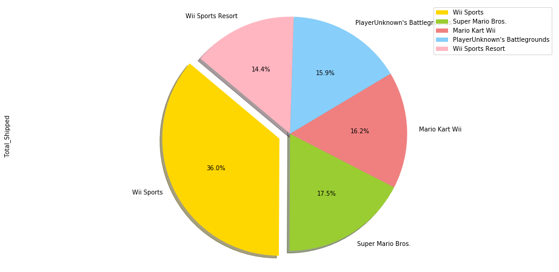

```python
#Data1 sudah terurut berdasarkan Global Sales dan Total Shipped
colors = ['gold', 'yellowgreen', 'lightcoral', 'lightskyblue', 'lightpink']
explode = (0.1, 0, 0, 0, 0)  # explode 1st slice

# Plot
data1[:5].plot(kind="pie", y="Total_Shipped", labels=data1["Name"], figsize=(16,8), explode=explode,
               colors=colors, autopct='%1.1f%%', shadow=True, startangle=140)
plt.axis('equal')
plt.show()
```

**Kesimpulan**: *Terlihat bahwa Wii Sports mendapatkan penjualan terbanyak diikuti oleh Super Mario Bros, Mario Kart Wii, PlayerUnknown's Battleground dan Wii Sports Resort.*

### 2. Platform dengan produksi game terbanyak

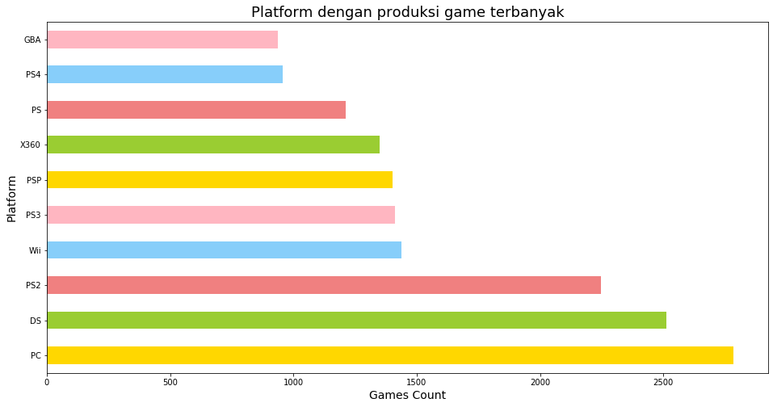

```python
data1["Platform"].value_counts()[:10].plot(kind="barh", figsize=(16,8), color=colors)
plt.xlabel('Games Count', fontsize=14)
plt.ylabel('Platform', fontsize=14)
plt.title("Platform dengan produksi game terbanyak", fontsize=18)
plt.show()
```

**Kesimpulan**: *Terlihat bahwa walaupun game-game dengan penjualan terbanyak berasal dari Wii, namun jumlah game terbanyak tetap dimenangkan oleh game PC*

### 3. Perkembangan produksi game pada masing-masing platform sejalan dengan waktu

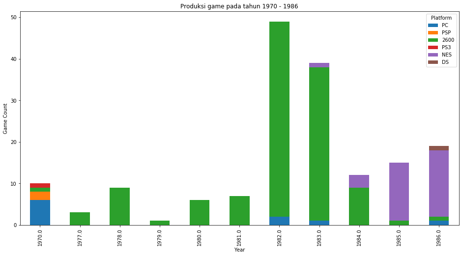

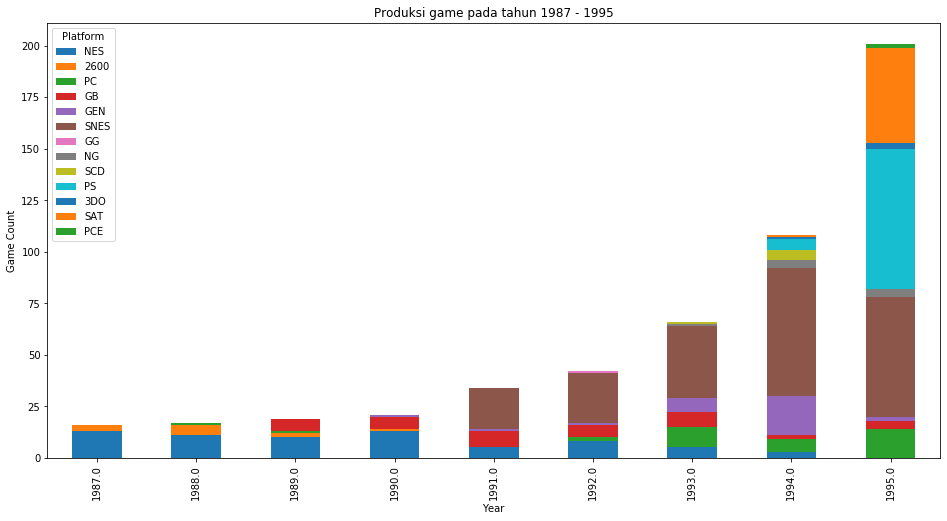

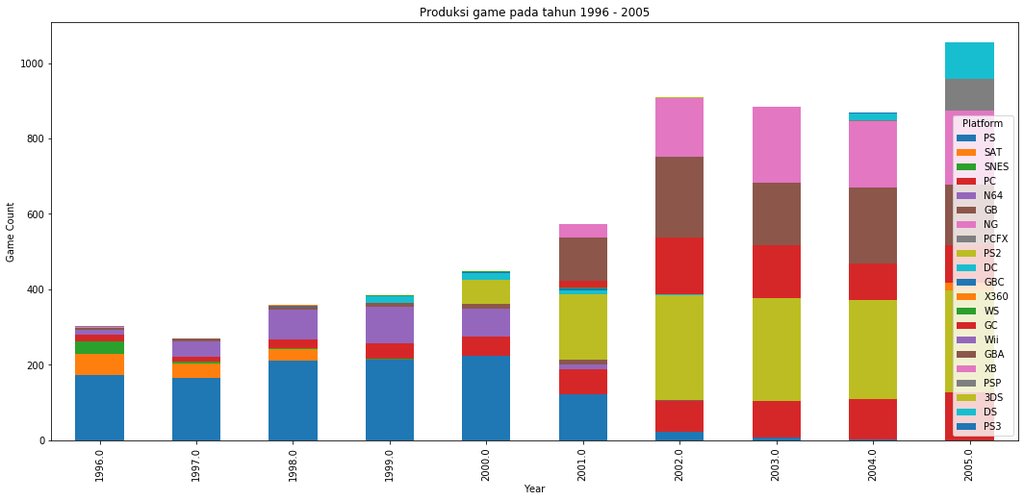

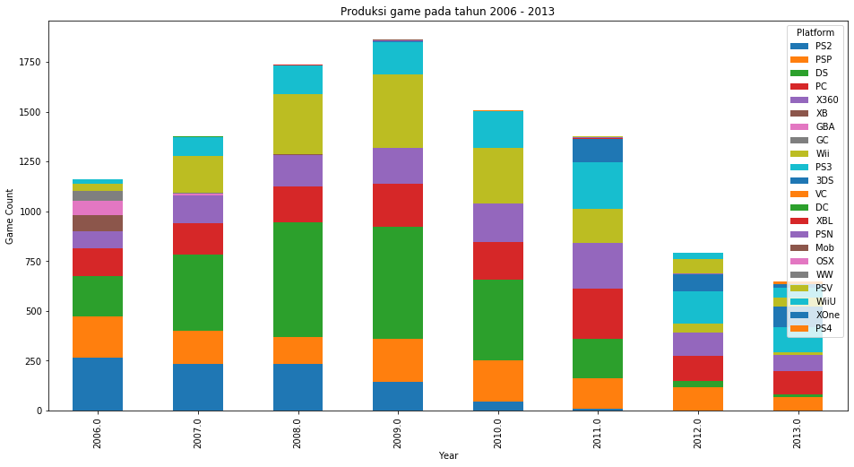

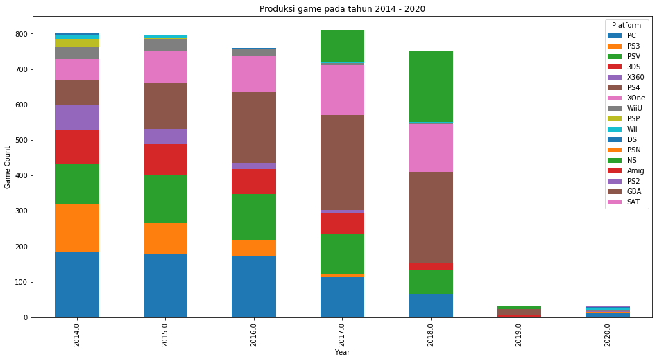

```python
#Melihat platform yang banyak dimainkan berdasarkan waktu
data1.groupby("Year")["Platform"].value_counts()[:22].unstack().plot(kind="bar", figsize=(16,8),stacked=True, legend=True)
plt.ylabel("Game Count")
plt.title("Produksi game pada tahun 1970 - 1986")
plt.show()
data1.groupby("Year")["Platform"].value_counts()[22:71].unstack().plot(kind="bar", figsize=(16,8),stacked=True, legend=True)
plt.ylabel("Game Count")
plt.title("Produksi game pada tahun 1987 - 1995")
plt.show()
data1.groupby("Year")["Platform"].value_counts()[71:163].unstack().plot(kind="bar", figsize=(18,8),stacked=True, legend=True)
plt.ylabel("Game Count")
plt.title("Produksi game pada tahun 1996 - 2005")
plt.show()
data1.groupby("Year")["Platform"].value_counts()[163:259].unstack().plot(kind="bar", figsize=(16,8),stacked=True, legend=True)
plt.ylabel("Game Count")
plt.title("Produksi game pada tahun 2006 - 2013")
plt.show()
data1.groupby("Year")["Platform"].value_counts()[259:].unstack().plot(kind="bar", figsize=(16,8),stacked=True, legend=True)
plt.ylabel("Game Count")
plt.title("Produksi game pada tahun 2014 - 2020")
plt.show()
```

**Kesimpulan**: *Melihat dari data tersebut dapat disimpulkan bahwa game mulai berkembang sangat pesat pada tahun 1991 dan aneka macam platform bermunculan seiringan dengan berjalannya waktu dan mulai kembali terpusat ke beberapa platform setelah memasuki abad ke 21. Pada tahun 2019 dan 2020, data yang diambil kurang karena data ini diambil pada awal tahun 2019 yang menyebabkan data kurang lengkap.*

### 4. Publisher dengan game terbanyak

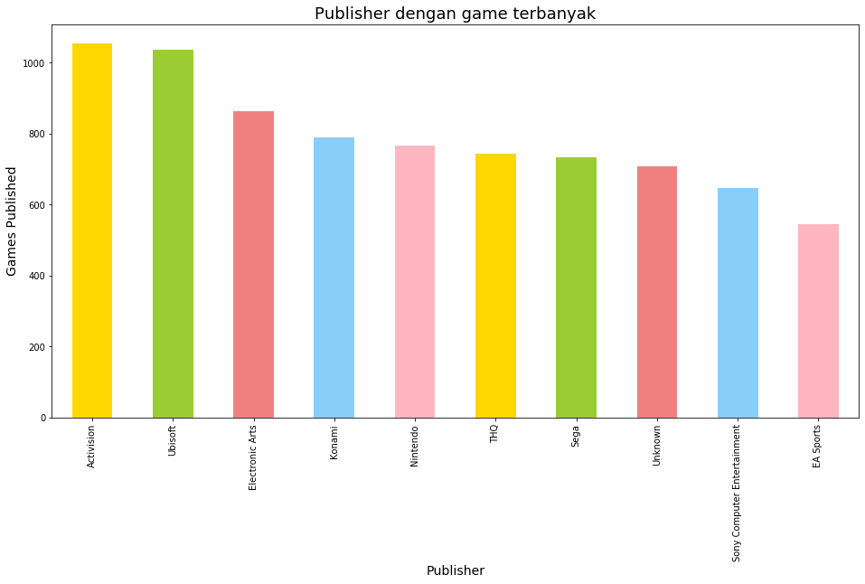

```python
data1["Publisher"].value_counts()[:10].plot(kind="bar", figsize=(16,8), color=colors)
plt.xlabel('Publisher', fontsize=14)
plt.ylabel('Games Published', fontsize=14)
plt.title("Publisher dengan game terbanyak", fontsize=18)
plt.show()
```

**Kesimpulan**: *Activision mengungguli setiap publisher lain dengan mempublish game terbanyak, diikuti oleh Ubisoft dan Electronic Arts.*

### 5. Developer dengan game terbanyak

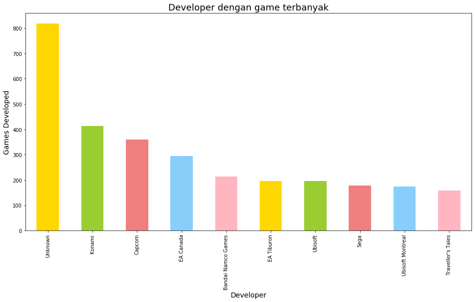

```python
data1["Developer"].value_counts()[:10].plot(kind="bar", figsize=(16,8), color=colors)
plt.xlabel('Developer', fontsize=14)
plt.ylabel('Games Developed', fontsize=14)
plt.title("Developer dengan game terbanyak", fontsize=18)
plt.show()
```

**Kesimpulan**: *Dengan melihat publisher dengan game terbanyak adalah Activision dan dengan melihat grafik developer dengan game terbanyak, maka dapat disimpulkan bahwa banyaknya game developer dan publisher tidak saling berkaitan.*

### 6. Perkembangan penjualan game setiap tahun

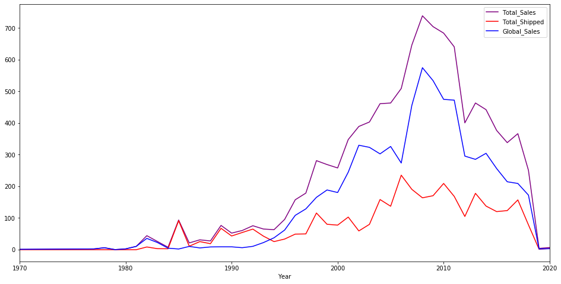

```python
data1['Total_Sales'] = data1.loc[:,['Total_Shipped','Global_Sales']].sum(axis=1)
#Total Sales dihitung dengan menjumlahkan total shipped dan global sales
data1.groupby("Year").sum().plot(kind="line", y=["Total_Sales", "Total_Shipped", "Global_Sales"], figsize=(16,8), color=['purple', 'red', 'blue'])
plt.show()
```

### 7. Genre dengan produksi game terbanyak

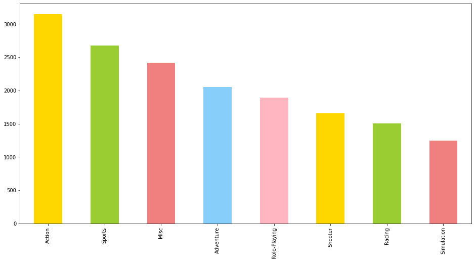

```python
data1["Genre"].value_counts()[:8].plot(kind="bar", figsize=(16,8),
               color=colors)
plt.show()
```

**Kesimpulan**: *Terlihat bahwa Action adalah genre yang paling disukai selama ini*

### 8. Genre yang paling disuka dalam masing-masing tahun produksi

**Dalam kasus kali ini, kami akan menganalisis pada tahun 2000-2020**

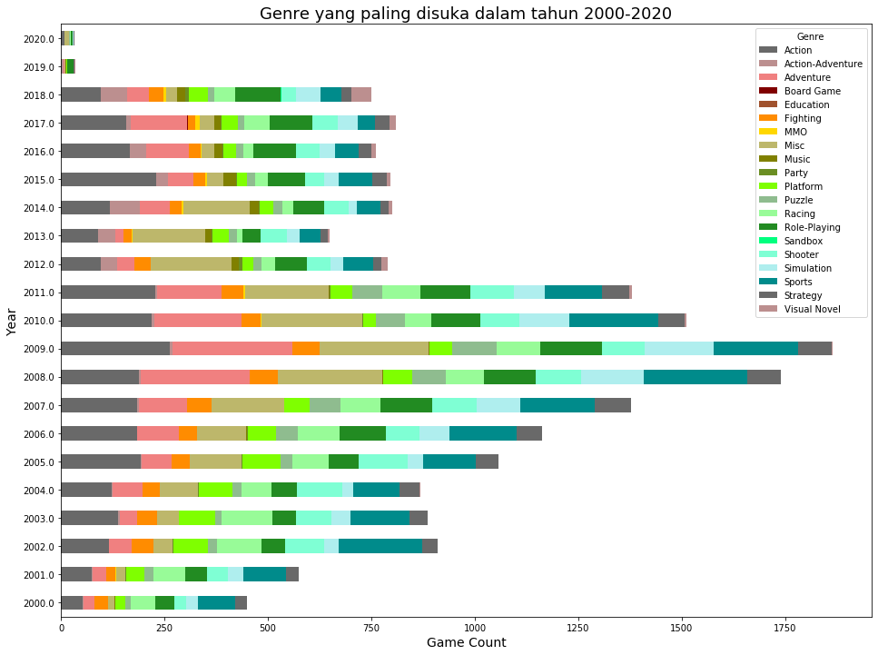

```python
goodColors = ['dimgray', 'rosybrown', 'lightcoral', 'maroon', 'sienna', 'darkorange', 'gold', 'darkkhaki', 'olive', 'olivedrab', 'chartreuse', 'darkseagreen', 'palegreen', 'forestgreen', 'springgreen', 'aquamarine', 'paleturquoise', 'darkcyan']
data1.groupby("Year")["Genre"].value_counts()[199:].unstack().plot(kind="barh", figsize=(16,12),stacked=True, legend=True, color=goodColors)
plt.title("Genre yang paling disuka dalam tahun 2000-2020", fontsize=18)
plt.xlabel("Game Count", fontsize=14)
plt.ylabel("Year", fontsize=14)
plt.show()
```

**Kesimpulan**: *Terlihat bahwa dalam tahun 2012 dan 2013 peminat untuk game Adventure dan Action berkurang, sedangkan pada tahun-tahun lain yang biasanya memimpin adalah Action, Adventure, Role-Playing atau Sports*

### 9. Banyaknya game sesuai kategori umur (ESRB Rating)

Diketahui bahwa:

- E : Everyone, untuk semua umur
- E10 : Everyone 10+, untuk umur 10 tahun keatas
- T : Teenager, untuk umur 13 tahun keatas
- M : Mature, untuk umur 17 tahun keatas

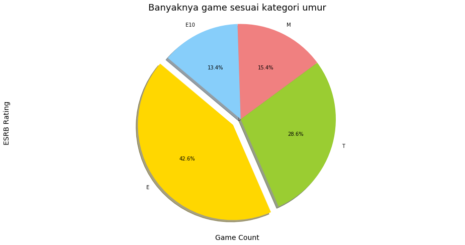

```python
data1["ESRB_Rating"].value_counts()[:4].plot(kind="pie", figsize=(16,8), explode=[0.1, 0, 0, 0],
               colors=colors, autopct='%1.1f%%', shadow=True, startangle=140)
plt.title("Banyaknya game sesuai kategori umur", fontsize=18)
plt.ylabel("ESRB Rating", fontsize=14)
plt.xlabel("Game Count", fontsize=14)
plt.axis('equal')
plt.show()
```

**Kesimpulan**: *Terlihat dengan jelas bahwa game paling banyak tersedia untuk semua usia dan selanjutnya diikuti oleh teenager/remaja dan game-game untuk 17 tahun keatas yang mengandung kekerasan, darah, konten dewasa, dan bahasa yang keras masih mengungguli dari game 10 tahun keatas yang mana lebih banyak masuk ke kategori teenager.*

# Korelasi

### 10. Relasi antara penjualan video games dengan penilaian video games dari pemain dan Metacritic

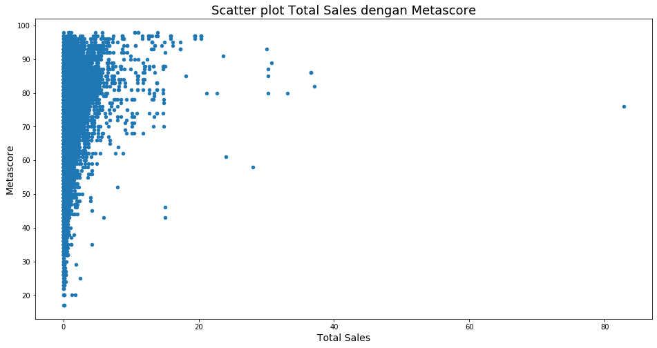

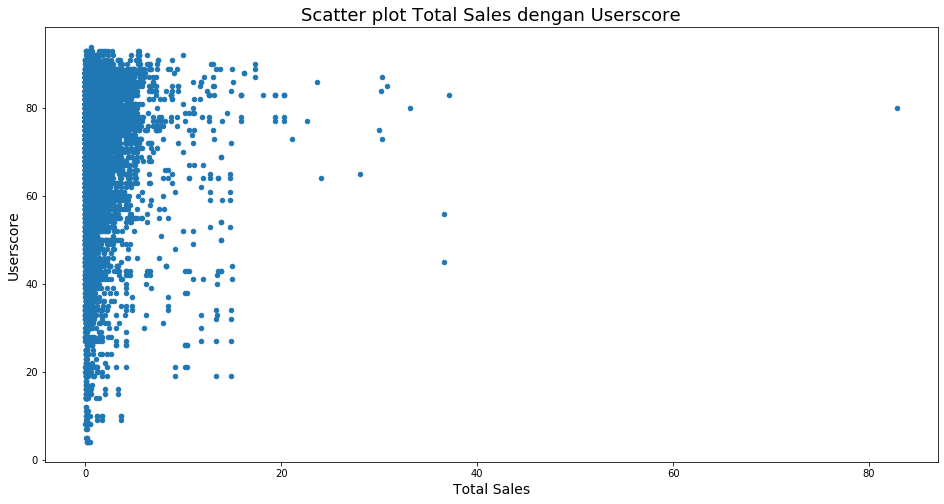

```python
data2.columns = ['metascore', 'Name', 'console', 'userscore', 'date']
dataMerged = pd.merge(data1, data2, how="outer", on="Name")
dataMerged.plot(kind="scatter", x="Total_Sales", y="metascore", figsize=(16,8))
plt.title("Scatter plot Total Sales dengan Metascore", fontsize=18)
plt.ylabel("Metascore", fontsize=14)
plt.xlabel("Total Sales", fontsize=14)
plt.show()
dataMerged.plot(kind="scatter", x="Total_Sales", y="userscore", figsize=(16,8))
plt.title("Scatter plot Total Sales dengan Userscore", fontsize=18)
plt.ylabel("Userscore", fontsize=14)
plt.xlabel("Total Sales", fontsize=14)
plt.show()
```

### 11. Relasi antara penilaian dari pemain dan metacritic

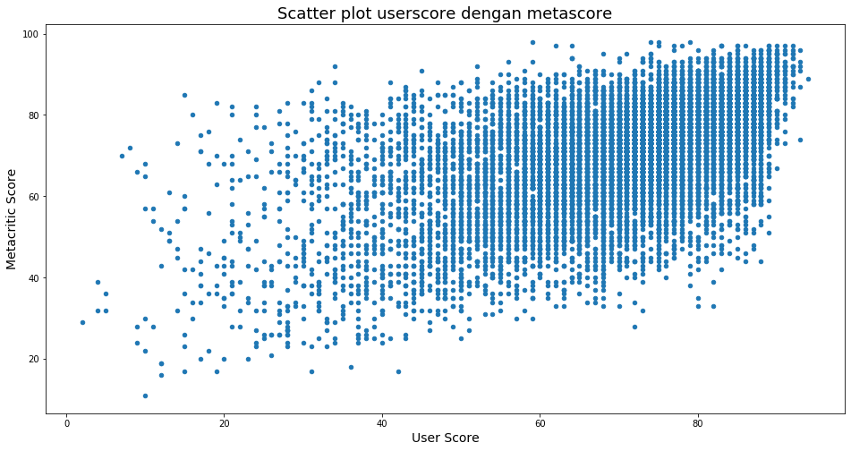

```python
data2.plot(kind="scatter", x="userscore", y="metascore", figsize=(16,8))
plt.title("Scatter plot userscore dengan metascore", fontsize=18)
plt.xlabel("User Score", fontsize=14)
plt.ylabel("Metacritic Score", fontsize=14)
plt.show()
```

### Korelasi antara Metascore, Userscore, Total Sales

```python
dataMerged.loc[:,["metascore", "userscore", "Total_Sales"]].corr()
```

|  | metascore | userscore | Total_Sales |
| --- | --- | --- | --- |
| metascore | 1.000000 | 0.520324 | 0.227263 |
| userscore | 0.520324 | 1.000000 | 0.035393 |
| Total_Sales | 0.227263 | 0.035393 | 1.000000 |

**Kesimpulan**: *Kita dapat melihat bahwa korelasi antara metascore, userscore dan total sales beragam. Pada baris pertama kita dapat menyimpulkan bahwa userscore dan metascore cukup berbanding lurus. Hal itu menyebabkan bahwa jika metascore tinggi cukup tinggi juga kemungkinan userscore tinggi. Kita dapat melanjutkan ke analisis selanjutnya, Total Sales dan Metascore kurang berbanding lurus, sehingga jika penjualan game besar belum tentu metascore besar. Hal ini menurut kami disebabkan oleh kemungkinan orang sudah membeli game tersebut sebelum mengetahui bahwa game itu tidak terlalu sesuai harapannya. Hal ini juga berlaku untuk Total Sales dan Userscore bahkan tidak berbanding lurus sama sekali.*